# Buckling-Constrained Truss Optimization with SDP Constraints

## Description

This tutorial demonstrates buckling-constrained topology optimization on a truss structure. The goal is to minimize compliance while ensuring the combined stiffness matrix `K + c·Kσ` remains positive semidefinite — i.e., the structure does not buckle under the applied load scaled by buckling factor `c`.

We use differentiable building blocks (`ElementK`, `AssembleK`, `TrussElementKσ`, `apply_boundary_with_zerodiag!`, `apply_boundary_with_meandiag!`) and enforce the PSD constraint via semidefinite programming (SDP) using NonconvexSemidefinite.jl with an IPM barrier method.

## Setup

```julia
using TopOpt, LinearAlgebra, Zygote
using Nonconvex, NonconvexSemidefinite, NonconvexIpopt
```

## Load Truss Geometry

Download the truss geometry file: tim_2d.json.

```julia
ndim = 2
node_points, elements, _, _, fixities, load_cases = load_truss_json(
    joinpath(@__DIR__, "tim_$(ndim)d.json")
)
ndim, nnodes, ncells = length(node_points[1]), length(node_points), length(elements)
loads = load_cases["0"]

# Override material and cross-section: a large area (A=800) makes the
# stiffness matrix K dominate the geometric stiffness Kσ, so the initial
# all-solid design is stable (K + c·Kσ ≻ 0) while still allowing the
# compliance-only optimum to go unstable.
mats = TrussFEAMaterial(1.0, 0.3)
crosssecs = TrussFEACrossSec(800.0)

problem = TrussProblem(
    Val{:Linear}, node_points, elements, loads, fixities, mats, crosssecs
)
```

## Parameter Settings

```julia
xmin = 0.0001   # minimum density
p = 1.0         # SIMP penalty exponent
V = 0.5         # volume fraction
x0 = fill(1.0, ncells)  # initial design (all solid)
```

## FEA Solver and Buckling Helpers

```julia
solver = FEASolver(DirectSolver, problem; xmin=xmin)
ch = problem.ch

comp = ComplianceFun(solver)
dp = DisplacementFun(solver)
assemble_k = AssembleKFun(problem)
element_k = ElementKFun(solver)
truss_element_kσ = TrussElementKσ(problem, solver)
```

Five differentiable building blocks:

1. **Compliance** — objective to minimize
2. **Displacement** — solves `K·u = f` for displacements
3. **ElementK** — per-element stiffness matrices
4. **AssembleK** — assembles global sparse matrix
5. **TrussElementKσ** — geometric (stress) stiffness matrices

## Buckling Constraint Function

```julia
c = 1.0  # buckling load multiplier — large enough that the constraint binds

function buckling_matrix_constr(x)
    xd = PseudoDensities(x)
    u = dp(xd)
    Kes = element_k(xd)
    K = assemble_k(Kes)
    K = apply_boundary_with_meandiag!(K, ch)
    Kσs = truss_element_kσ(u, xd)
    Kσ = assemble_k(Kσs)
    Kσ = apply_boundary_with_zerodiag!(Kσ, ch)
    return Array(K + c * Kσ)
end
```

The constraint returns the combined matrix `K + c·Kσ` which must be PSD (all eigenvalues ≥ 0).

## Check Initial Design

```julia
S0 = buckling_matrix_constr(x0)
println("Initial design minimum eigenvalue: $(minimum(eigen(S0).values))")
```

```
Initial design minimum eigenvalue: 0.3412528944345227
```

The initial all-solid design should have positive eigenvalues (stable).

## Volume Constraint

```julia
vol_constr(x) = sum(x) / length(x) - V
```

## Compliance-Only Optimization (Baseline)

```julia
obj = x -> comp(PseudoDensities(x))

model = Model(obj)
addvar!(model, zeros(length(x0)), ones(length(x0)))
add_ineq_constraint!(model, vol_constr)

alg = MMA87()
options = MMAOptions(; maxiter=200, tol=Tolerance(; kkt=1e-4))
r1 = optimize(model, alg, x0; options=options)

println("ComplianceFun-only result:")
println("  obj = $(obj(r1.minimizer))")
println("  vol = $(vol_constr(r1.minimizer))")
```

```
[ Info:   iter       obj      Δobj  violation  kkt_residual
[ Info:      0   5.4e-03       Inf   5.0e-01   5.0e-01
[ Info:      1   9.8e-03   4.4e-03   5.0e-02   2.4e+32
[ Info:      2   9.3e-03   4.7e-04   0.0e+00   8.1e-04
[ Info:      3   7.9e-03   1.5e-03   0.0e+00   3.8e-04
[ Info:      4   6.8e-03   1.1e-03   0.0e+00   1.2e-03
[ Info:      5   6.2e-03   6.0e-04   0.0e+00   1.9e-04
[ Info:      6   6.2e-03   6.6e-06   0.0e+00   6.0e-05
ComplianceFun-only result:
  obj = 0.006161931529729129
  vol = -0.016356884179759223
```

This baseline ignores buckling — the result may be unstable.

## Add Buckling SDP Constraint

```julia
# Add semidefinite constraint: K + c·Kσ ≽ 0
add_sd_constraint!(model, buckling_matrix_constr)

alg2 = SDPBarrierAlg(; sub_alg=IpoptAlg())
options2 = SDPBarrierOptions(;
    sub_options=IpoptOptions(; max_iter=200),
    keep_all=true
)
r2 = optimize(model, alg2, x0; options=options2)

println("Buckling-constrained result:")
println("  obj = $(obj(r2.minimizer))")
println("  vol = $(vol_constr(r2.minimizer))")
```

[output not shown]

[output cut: 876 more lines]

```
Warning: Cutting back alpha due to evaluation error
 132  6.0880420e-03 0.00e+00 1.10e-05  -8.1 8.08e-03    -  1.00e+00 1.53e-05h 17
 133  6.0880417e-03 0.00e+00 1.29e-05  -8.1 5.06e-02    -  1.00e+00 3.91e-03h  9
Warning: Cutting back alpha due to evaluation error
Warning: Cutting back alpha due to evaluation error
 134  6.0880416e-03 0.00e+00 1.13e-05  -8.1 1.46e-02    -  1.00e+00 7.81e-03h  8
 135  6.0880416e-03 0.00e+00 1.21e-05  -8.1 4.31e-03    -  1.00e+00 3.12e-02h  6
Warning: Cutting back alpha due to evaluation error
Warning: Cutting back alpha due to evaluation error
Warning: Cutting back alpha due to evaluation error
Warning: Cutting back alpha due to evaluation error
 136  6.0880409e-03 0.00e+00 6.69e-06  -8.1 2.80e-02    -  1.00e+00 6.25e-02f  5
Buckling-constrained result:
  obj = 0.006087973737295718
  vol = -8.77306768343189e-8
```

The `SDPBarrierAlg` uses an interior-point method with log-barrier for PSD constraints. IPOPT solves the continuous subproblems.

## Check Stability

```julia
S1 = buckling_matrix_constr(r1.minimizer)
S2 = buckling_matrix_constr(r2.minimizer)

ev1 = eigen(S1).values
ev2 = eigen(S2).values

println("ComplianceFun-only min eigenvalue: $(minimum(ev1))")
println("Buckling-constrained min eigenvalue: $(minimum(ev2))")
println("Design is stable: $(minimum(ev2) ≥ -1e-6)")
```

```
ComplianceFun-only min eigenvalue: -1.7999557695227362
Buckling-constrained min eigenvalue: 8.177758090264977e-9
Design is stable: true
```

The buckling-constrained design should have non-negative eigenvalues (stable under load), while the compliance-only design may have negative eigenvalues (unstable).

## Visualization

[output not shown]

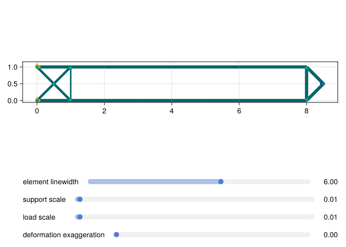

```julia
using Makie, CairoMakie

fig1 = visualize(problem; solver.u, topology=r1.minimizer, default_exagg_scale=0.0)
fig2 = visualize(problem; solver.u, topology=r2.minimizer, default_exagg_scale=0.0)
```

The buckling-constrained design typically shows thicker compression members and more stable load paths compared to the compliance-only design.